# Incarceration Records

Iman Malik

2024-10-30

## 1. Introduction

[This dataset](https://data.texas.gov/dataset/High-Value-Dataset-July-2024/qz8r-du54/about_data) examines incarceration records from Travis County, Texas, in July 2024, obtained from the [Texas Open Data Portal](https://data.texas.gov/), a public resource offering datasets on a wide range of state-related information. The dataset provides information about inmates and their demographics, offense details, sentence dates and lengths, and also additional information including SID numbers, TDCJ numbers, offense dates, and parole details. I chose this dataset to investigate patterns in incarceration within a specific county. I will be focusing on demographic distributions, offense types, and sentencing trends. I will be analyzing relationships between demographic factors, case types, and sentencing outcomes.

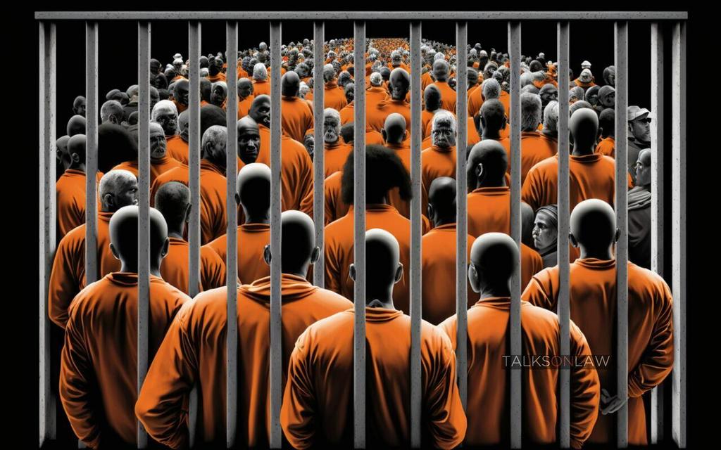

Image source: [Talks on Law](https://www.talksonlaw.com/talks/confronting-mass-incarceration)

## 2. Data Preparation

I downloaded the CSV file for this data from the Texas Open Data Portal– it was already in a downloadable format, no scraping necessary. There were some variables that I did not want to include, so in my final subset I made sure to only select the variables I needed. I also wanted to only look at inmates who offended in Travis County, so I filtered the data to include only those observations. There were 2 dates in the dataset, so I parsed those into date variables I could more easily work with to create a new numeric variable. I also created a new variable by manipulating an existing string variable. There were some NA date values, and they caused some NA values for my new numeric variable, but I did not take them out because R automatically removed them to make a scatterplot, and I still wanted to use those observations and examine the other non-NA variables for them. A challenge I faced was figuring out what to do with non-numeric Sentence values and special cases, but I ultimately decided to remove those observations all together to have a more cohesive analysis.

## 3. Variable Descriptions

| Variable Name | Type | Description |
| --- | --- | --- |
| Name | Character | The name of the inmate |
| Gender | Character | The gender of the inmate |
| Age | Numeric | The current age of the inmate |
| Race | Character | The race of the inmate |
| Offense | Character | The crime committed by the inmate |
| Sentence Date | Date | The date that the inmate was sentenced to prison |
| Projected Release | Date | The estimated date the inmate will be released from prison |
| Sentence | Numeric | The length of time, in years, that the inmate is serving in prison |
| Estimated Sentence | Numeric | The estimated length of time, in years, that the inmate will serve in prison, calculated by the difference between Sentence Date and Projected Release |
| Murder | Character | States whether a case is a murder case or not |

## 4. Univariate Analyses

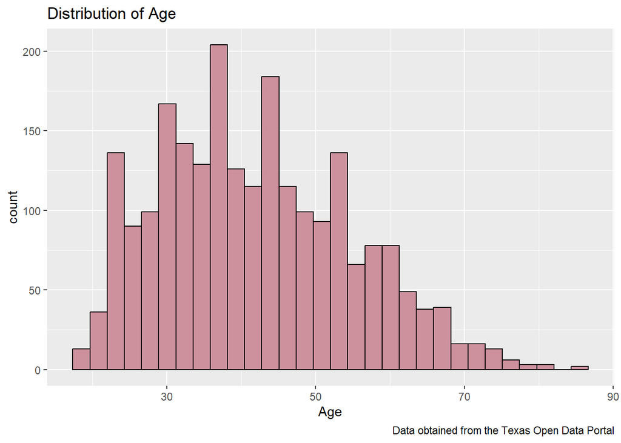

The distribution of age is slightly right-skewed, with a mean of 41.881 and a median of 41. These two values are close together, indicating the distribution is somewhat balanced. The spread is described by the standard deviation, 12.806, and the interquartile range, 19.

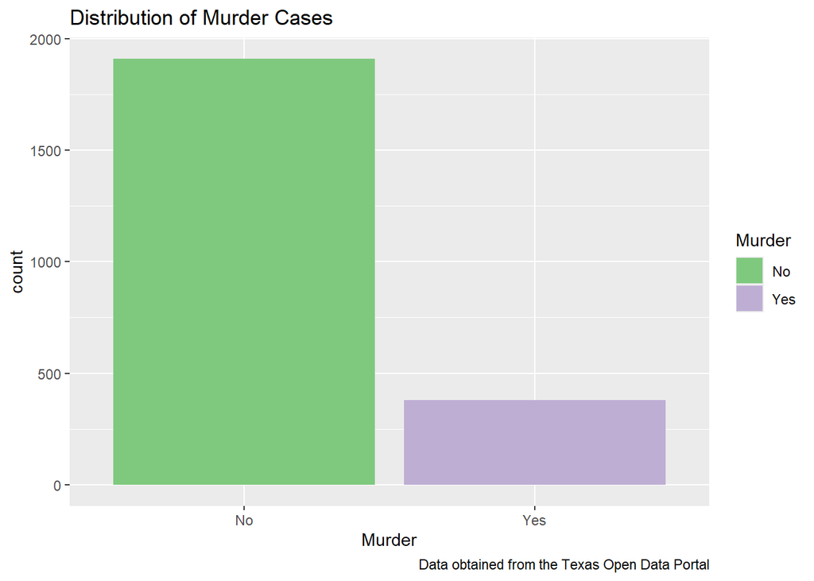

A majority of cases for inmates from Travis County are not murder cases. Only 16.6% of cases are murder cases, while 83.4% of cases are non-murder cases.

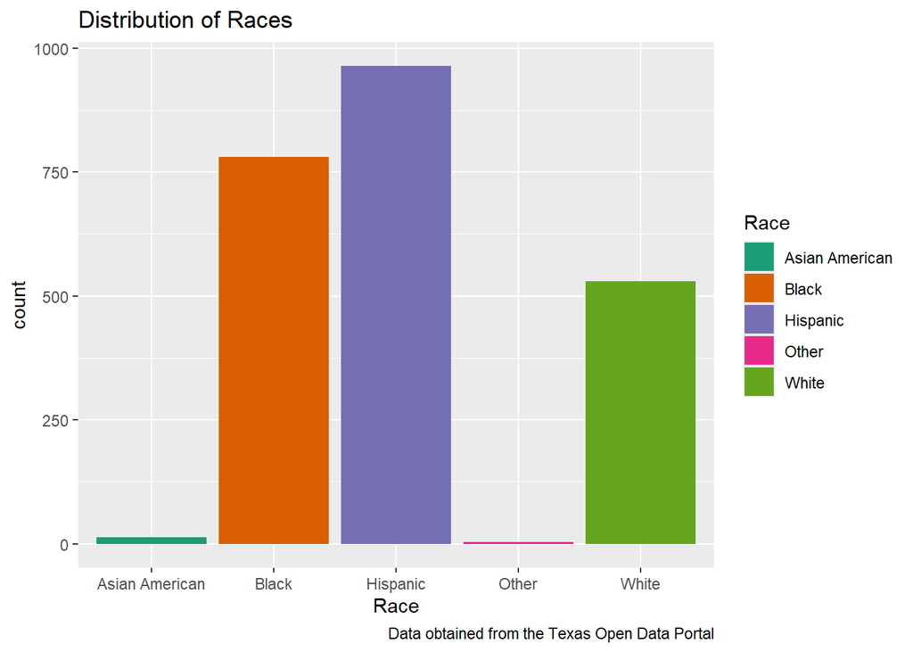

From Travis County, 42.1% of inmates are Hispanic, 34.1% of inmates are Black, 23.1% of inmates are White, 0.6% of inmates are Asian American, and 0.2% of inmates are another race.

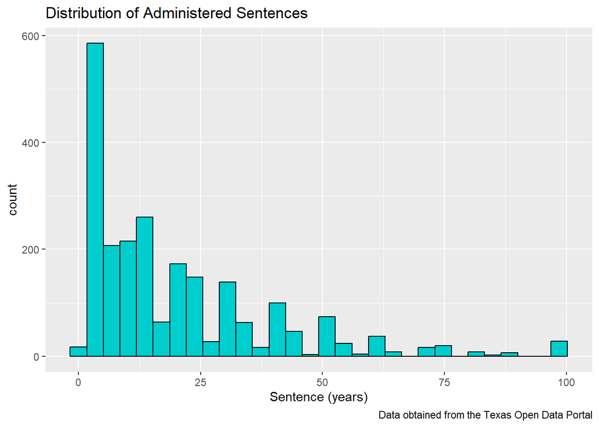

## 5. Bivariate Analyses

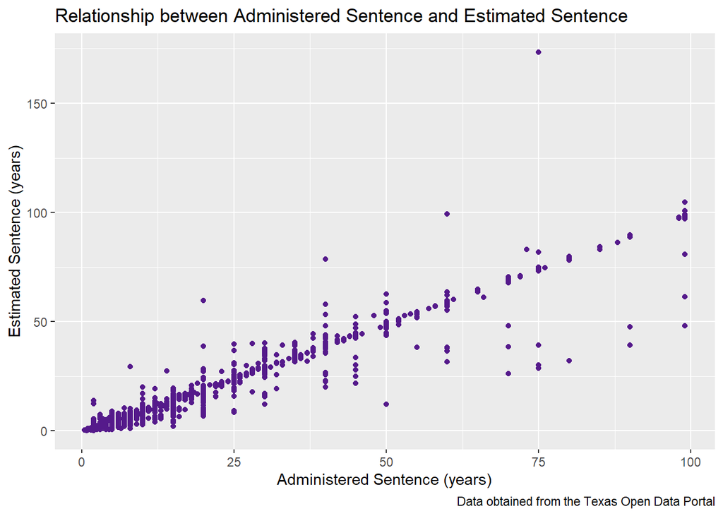

The plots follow a linear pattern with some deviations. The correlation coefficient for the relationship between administered sentences and estimated sentences is 0.969. This indicates a strong, positive correlation. So typically, the estimated sentence that an inmate serves will closely match the length of time administered to them at their sentencing.

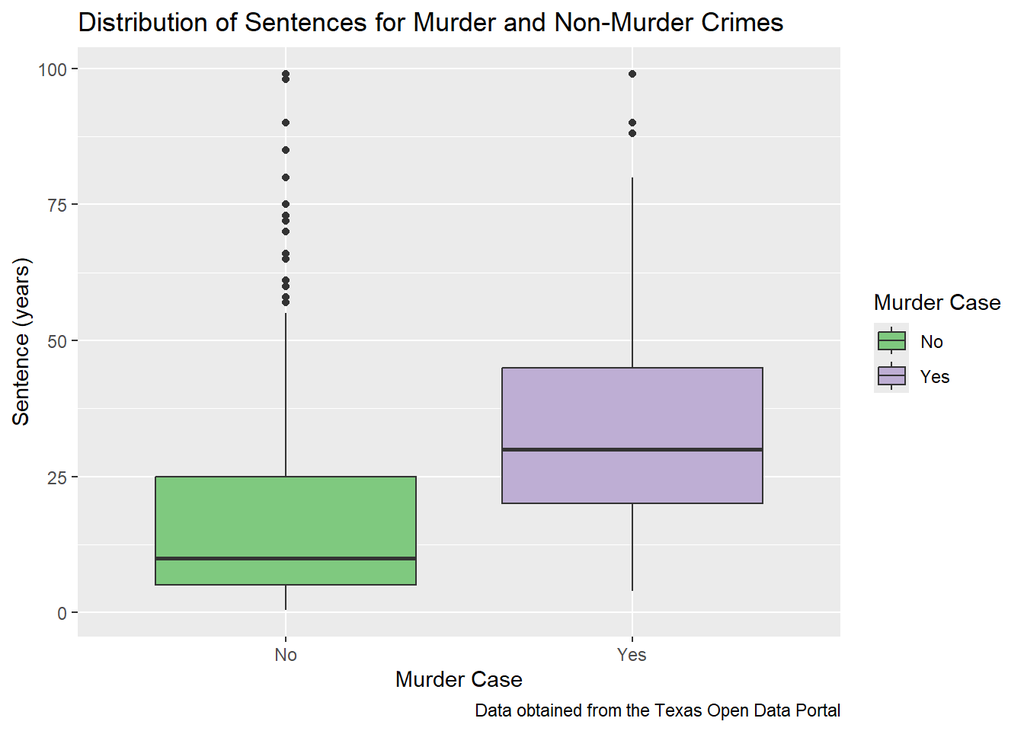

As shown by the boxplots, murder cases have a higher median sentence than non-murder cases. Non-murder cases have more outliers due to the variety in the type of cases, but murder cases have a larger maximum of over 75 years (not including outliers). Murder cases also have a larger minimum sentence than non-murder cases.

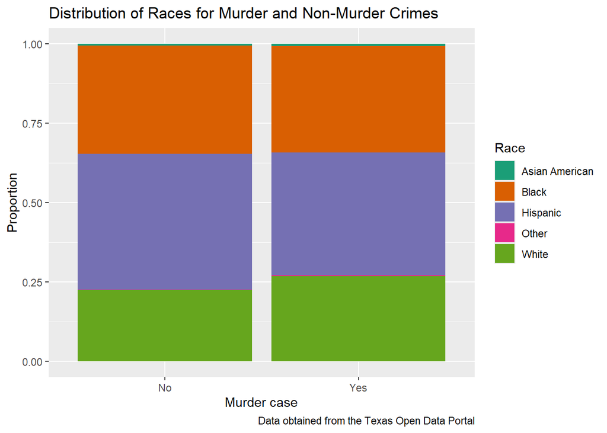

From Travis County, the race group that makes up the most population of inmates is Hispanic, at 42.8% for non-murder cases and 38.7% for murder cases. The percentage of white inmates increases for murder cases, from 22.3% to 26.8%. This is also the case for Asian Americans (0.5% to 0.6%) and inmates of other race groups (0.2% to 0.3%). Meanwhile, the Hispanic proportion goes down from 42.8% to 38.7%, as well as the Black population, which decreases from 34.2% to 33.4%.

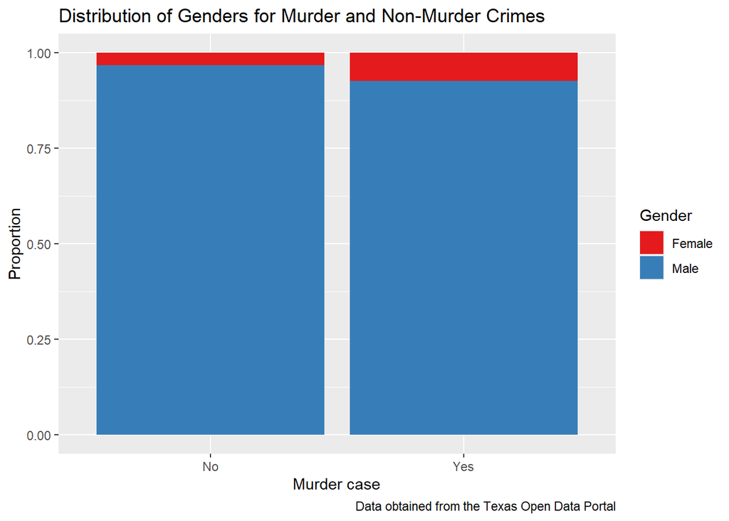

For non-murder cases, females make up 3.3% of them while males make up 96.7% of them. Meanwhile, for murder cases, females make up more of the percentage at 7.4%, while males make up 92.6% of them.

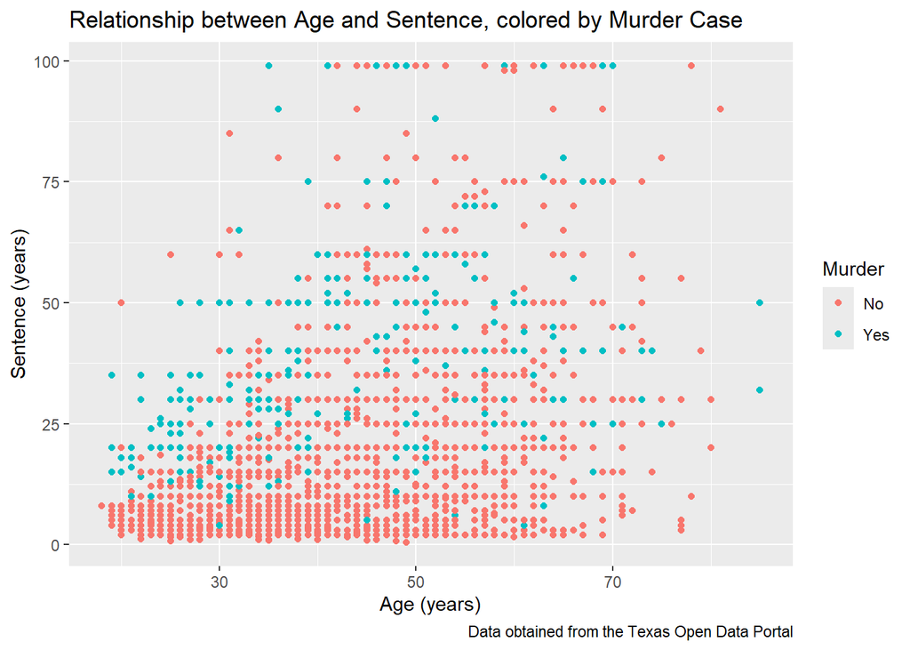

There seems to not be much of a relationship between sentence and age. However, the graph shows clumps of red plots at the bottom while the blue plots are scattered more upwards, indicating that murder cases typically get higher sentences than non-murder cases. Additionally, some older inmates have higher sentences, which could be attributed to the fact that they have been there for decades.

## 6. Reproducibility Resources

All files needed to reproduce this report can be found on [my Github repository](https://github.com/imanmalik16/Project-2-Incarceration-Records).

## 7. Choice Elements

For my choice elements, I used in-line code throughout my report for descriptive statistics. I implemented this to show specific values for my statistics and integrate it into my report, rather than generating code output. I parsed the *Sentence Date* and *Projected Release* dates into date variables that R could easily read. I did this so I could better measure the dates and use it to create a new variable. I also formatted string values from *Offense*, and I did this by detecting certain words in order to make a new variable. I created two new variables: *Estimated_Sentence* (I created this by finding the difference in time in years between the sentencing date and the projected release date) and *Murder* (I created this by using string manipulation to detect “Murder” and “Manslaughter” to determine whether a case was a murder case or not). At the end of my bivariate analyses, I made a multivariate plot including *Age*, *Sentence*, and *Murder*. I did this to analyze whether there was a relationship between the age of inmates and their sentences based on whether they were convicted of a murder crime or not.

## 8. Conclusion

By analyzing the incarceration records for Travis County, I noticed several patterns. The age distribution of inmates is moderately balanced yet slightly right-skewed, indicating a predominance of younger to middle-aged individuals. A majority of cases were non-murder crimes. Racial disparities were evident, as Hispanic and Black individuals together made up over 75% of inmates, possibly reflecting systemic influences or a higher population of minorities in Travis County. Sentence lengths had a right-skewed distribution, though a few outliers significantly extended the distribution. Murder cases also had longer sentence lengths and larger minimum lengths, which is expected. Additionally, I analyzed a relationship between administered sentence length and estimated time served, suggesting that projected release date calculations tend to be accurate; however, there are some cases in which inmates served longer or shorter sentences, and this could be attributed to behavior or parole. These results align with trends in demographic and sentence length distributions.

## 9. References

[Texas Open Data Portal](https://data.texas.gov/), [Racial Disparity in Imprisonment](https://www.sentencingproject.org/publications/one-in-five-racial-disparity-in-imprisonment-causes-and-remedies/), [Definitions & Acronyms](https://www.tdcj.texas.gov/definitions/index.html#:~:text=Projected%20Release%20Date.,offense%20title%20and%20offense%20date.), [Talks on Law](https://www.talksonlaw.com/talks/confronting-mass-incarceration)